# RETRASCORE Validation Report

# 1 Setup instructions

1. Put the RETRASCORE CSV in this project directory. If it is the **only input CSV**, render this file as-is.
2. If there is more than one CSV, set `params$csv_path` to the intended file (absolute, or relative to this `.Rmd`). For example:

   ```r
   rmarkdown::render("RETRASCORE_validation.Rmd",
                     params = list(csv_path = "data/retrascore.csv"))
   ```

3. Column names are matched case-insensitively after punctuation and spaces are removed. The accepted aliases are printed in the **Column mapping** section. If a required concept has no unique match, the report stops with a diagnostic telling you what to rename.
4. Binary fields accept `1/0`, `yes/no`, `true/false`, `present/absent`, `positive/negative`, and common Spanish/Catalan equivalents. Unrecognised values remain missing (`NA`); they are never silently converted to zero.
5. Patient-level calculations are exported to `outputs/retrascore_patient_level.csv`. The source CSV is never overwritten.

The model probability is calculated as `1 / (1 + exp(-y))`. Classification uses a probability cutoff of `params$probability_cutoff` (default **0.5**) unless the input contains a single valid value in a recognised cutoff column. Yearly validation is grouped by every integer value actually present in the existing `retrascore` column. Patients without an existing RETRASCORE remain `NA` and are excluded only from score-by-year summaries.

```r
normalise_name <- function(x) {
  x <- iconv(x, from = "", to = "ASCII//TRANSLIT")
  tolower(gsub("[^[:alnum:]]", "", x))
}

aliases <- list(
  patient_id = c("patient_id", "patientid", "id_patient", "idpatient", "record_id", "recordid", "id", "historia"),
  age = c("age", "age_years", "ageyears", "edad", "edat"),
  precoag = c("precoag", "pre_coag", "preinjury_coagulopathy", "preexisting_coagulopathy",
              "pretrauma_coagulopathy", "anticoagulation", "anticoagulant", "rscore_aco"),
  prehospital_intubation = c("prehospital_intubation", "prehospitalintubation", "pre_hospital_intubation",
                             "intubation_prehospital", "prehospital_eti", "intubacion_prehospitalaria",
                             "intubacio_prehospitalaria", "iot_prehospitalaria"),
  high_risk_mechanism = c("high_risk_mechanism", "highriskmechanism", "high_energy_mechanism",
                          "highenergymechanism", "mechanism_high_risk", "mecanismo_alto_riesgo",
                          "mecanisme_alt_risc", "rscore_mec"),
  pupil_status = c("pupil_status", "pupillary_status", "pupils", "mydriasis", "pupil_reactivity",
                   "estado_pupilar", "estat_pupillar", "pupilas_ingreso"),
  unilateral_mydriasis = c("unilateral_mydriasis", "unilateralmydriasis", "one_fixed_pupil",
                           "single_mydriasis", "midriasis_unilateral"),
  bilateral_mydriasis = c("bilateral_mydriasis", "bilateralmydriasis", "two_fixed_pupils",
                          "double_mydriasis", "midriasis_bilateral"),
  gcs = c("gcs", "glasgow", "glasgow_coma_scale", "glasgowcomascale", "initial_gcs", "gcs_initial", "gcs_total_introducido"),
  gcs_le_8 = c("gcs_le_8", "gcs8", "glasgow_le_8", "glasgow8", "gcs_less_equal_8"),
  mais_head = c("mais_head", "maishead", "head_mais", "mais_head_score", "mais_cabeza", "mais_cap", "mais1"),
  mais_thorax = c("mais_thorax", "maisthorax", "thorax_mais", "chest_mais", "mais_chest",
                  "mais_torax", "mais_toracic", "mais3"),
  haemodynamic_failure = c("haemodynamic_failure", "hemodynamic_failure", "haemodynamicfailure",
                           "hemodynamicfailure", "circulatory_failure", "shock", "fracaso_hemodinamico",
                           "fallada_hemodinamica", "situacion_hemodinamica"),
  respiratory_failure = c("respiratory_failure", "respiratoryfailure", "resp_failure",
                          "fracaso_respiratorio", "fallada_respiratoria", "adrs"),
  coagulopathy = c("coagulopathy", "trauma_coagulopathy", "coagulopatia"),
  mechanical_ventilation = c("mechanical_ventilation", "mechanicalventilation", "ventilated",
                             "ventilator", "ventilacion_mecanica", "ventilacio_mecanica", "vmec_dico"),
  massive_haemorrhage = c("massive_haemorrhage", "massive_hemorrhage", "massivehaemorrhage",
                          "massivehemorrhage", "massive_bleeding", "hemorragia_masiva",
                          "hemorragia_massiva", "hemorragia_masiva"),
  death = c("death", "died", "mortality", "in_hospital_death", "inhospitaldeath", "outcome_death",
            "fallecido", "exitus", "mort", "mortality_30d"),
  death_icu = c("evolucion_uci", "icu_outcome"),
  death_hospital = c("evolucion_hospitalaria", "hospital_outcome"),
  year = c("year", "admission_year", "admissionyear", "trauma_year", "case_year", "ano", "anio", "any"),
  admission_date = c("admission_date", "admissiondate", "date_admission", "trauma_date", "date", "fecha", "data", "fecha_trauma"),
  existing_probability = c("retrascore_probability", "retrascoreprobability", "retrascore_prob",
                           "predicted_probability", "predictedprobability", "mortality_probability",
                           "probability"),
  existing_score = c("retrascore", "retra_score", "retrascore_points", "retrascore_score"),
  group = c("retrascore_group", "retrascoregroup", "risk_group", "riskgroup", "probability_band",
            "probabilityband", "score_group", "group", "grupo_riesgo", "grup_risc"),
  cutoff = c("probability_cutoff", "probabilitycutoff", "classification_cutoff", "classificationcutoff",
             "risk_cutoff", "cutoff", "threshold")
)
aliases <- lapply(aliases, normalise_name)

find_column <- function(data, concept, required = FALSE) {
  hits <- names(data)[normalise_name(names(data)) %in% aliases[[concept]]]
  if (length(hits) > 1L) {
    stop(sprintf("Ambiguous mapping for '%s': %s. Keep or rename exactly one of these columns.",
                 concept, paste(hits, collapse = ", ")), call. = FALSE)
  }
  if (!length(hits)) {
    if (required) {
      stop(sprintf("Missing required concept '%s'. Accepted aliases: %s. Available columns: %s",
                   concept, paste(aliases[[concept]], collapse = ", "), paste(names(data), collapse = ", ")),
           call. = FALSE)
    }
    return(NA_character_)
  }
  hits
}

parse_binary <- function(x, field) {
  if (is.logical(x)) return(as.integer(x))
  raw <- trimws(tolower(iconv(as.character(x), from = "", to = "ASCII//TRANSLIT")))
  raw[raw %in% c("", "na", "n/a", "null", "missing", ".")] <- NA_character_
  yes <- c("1", "yes", "y", "true", "t", "present", "positive", "si", "s", "oui",
           "si, con empleo de dispositivos de apoyo")
  no  <- c("0", "no", "n", "false", "f", "absent", "negative")
  out <- rep(NA_integer_, length(raw))
  out[!is.na(raw) & raw %in% yes] <- 1L
  out[!is.na(raw) & raw %in% no] <- 0L
  bad <- sort(unique(raw[!is.na(raw) & is.na(out)]))
  if (length(bad)) {
    warning(sprintf("'%s': unrecognised binary value(s) retained as NA: %s",
                    field, paste(utils::head(bad, 12L), collapse = ", ")), call. = FALSE)
  }
  out
}

parse_number <- function(x, field) {
  raw <- trimws(as.character(x))
  raw[raw %in% c("", "NA", "N/A", ".")] <- NA_character_
  out <- suppressWarnings(as.numeric(gsub(",", ".", raw, fixed = TRUE)))
  bad <- sort(unique(raw[!is.na(raw) & is.na(out)]))
  if (length(bad)) {
    warning(sprintf("'%s': non-numeric value(s) retained as NA: %s",
                    field, paste(utils::head(bad, 12L), collapse = ", ")), call. = FALSE)
  }
  out
}

parse_pupils <- function(x) {
  raw <- trimws(tolower(iconv(as.character(x), from = "", to = "ASCII//TRANSLIT")))
  raw[raw %in% c("", "na", "n/a", "null", "missing", ".")] <- NA_character_
  normal <- c("0", "none", "normal", "reactive", "no", "absent", "sin midriasis", "sin alteraciones")
  unilateral <- c("1", "unilateral", "one", "one fixed", "single", "left", "right", "midriasis unilateral")
  bilateral <- c("2", "bilateral", "both", "both fixed", "double", "midriasis bilateral", "midriasis bilatera")
  uni <- bi <- rep(NA_integer_, length(raw))
  uni[!is.na(raw) & raw %in% normal] <- 0L; bi[!is.na(raw) & raw %in% normal] <- 0L
  uni[!is.na(raw) & raw %in% unilateral] <- 1L; bi[!is.na(raw) & raw %in% unilateral] <- 0L
  uni[!is.na(raw) & raw %in% bilateral] <- 0L; bi[!is.na(raw) & raw %in% bilateral] <- 1L
  bad <- sort(unique(raw[!is.na(raw) & is.na(uni)]))
  if (length(bad)) warning(sprintf("'pupil_status': unrecognised value(s) retained as NA: %s",
                                   paste(utils::head(bad, 12L), collapse = ", ")), call. = FALSE)
  list(unilateral = uni, bilateral = bi)
}

parse_sparse_indicator <- function(x, field) {
  # RETRAUCI stores derived rscore_aco/rscore_mec indicators as 1 when
  # present and blank when absent. Other non-missing values are not assumed.
  raw <- trimws(tolower(iconv(as.character(x), from = "", to = "ASCII//TRANSLIT")))
  out <- rep(NA_integer_, length(raw))
  out[raw == "1"] <- 1L
  out[raw == ""] <- 0L
  raw[raw %in% c("na", "n/a", "nas", "null", "missing", ".")] <- NA_character_
  bad <- sort(unique(raw[!is.na(raw) & !raw %in% c("", "1")]))
  if (length(bad)) warning(sprintf("'%s': unexpected sparse-indicator value(s) retained as NA: %s",
                                   field, paste(utils::head(bad, 12L), collapse = ", ")), call. = FALSE)
  out
}

parse_retrauci_mais <- function(x, field) {
  # In RETRAUCI, an empty regional MAIS cell means no injury in that region (0),
  # whereas explicit NA/NAS remains unknown.
  raw <- trimws(as.character(x))
  out <- suppressWarnings(as.numeric(gsub(",", ".", raw, fixed = TRUE)))
  out[raw == ""] <- 0
  unknown <- tolower(raw) %in% c("na", "n/a", "nas", "null", "missing", ".")
  out[unknown] <- NA_real_
  bad <- sort(unique(raw[raw != "" & !unknown & is.na(out)]))
  if (length(bad)) warning(sprintf("'%s': non-numeric value(s) retained as NA: %s",
                                   field, paste(utils::head(bad, 12L), collapse = ", ")), call. = FALSE)
  out
}

parse_haemodynamic <- function(x) {
  raw <- trimws(tolower(iconv(as.character(x), from = "", to = "ASCII//TRANSLIT")))
  out <- rep(NA_integer_, length(raw))
  out[raw == "estable"] <- 0L
  out[raw %in% c("inestable remonta con volumen", "shock", "shock refractario")] <- 1L
  out
}

parse_respiratory <- function(x) {
  raw <- trimws(tolower(iconv(as.character(x), from = "", to = "ASCII//TRANSLIT")))
  out <- rep(NA_integer_, length(raw))
  out[raw == "no"] <- 0L
  out[raw %in% c("201 -300", "> 300", "101-200", "<100")] <- 1L
  out
}

parse_outcome_death <- function(x) {
  raw <- trimws(tolower(iconv(as.character(x), from = "", to = "ASCII//TRANSLIT")))
  out <- rep(NA_integer_, length(raw))
  out[raw == "alta"] <- 0L
  out[raw %in% c("exitus", "exitus y donacion")] <- 1L
  out
}

read_input_csv <- function(path) {
  first <- readLines(path, n = 1L, warn = FALSE, encoding = "UTF-8")
  counts <- c(comma = lengths(regmatches(first, gregexpr(",", first, fixed = TRUE))),
              semicolon = lengths(regmatches(first, gregexpr(";", first, fixed = TRUE))),
              tab = lengths(regmatches(first, gregexpr("\t", first, fixed = TRUE))))
  sep <- c(comma = ",", semicolon = ";", tab = "\t")[[names(which.max(counts))]]
  message("Detected delimiter: ", if (sep == "\t") "TAB" else shQuote(sep))
  utils::read.table(path, header = TRUE, sep = sep, quote = "\"", comment.char = "",
                    check.names = FALSE, stringsAsFactors = FALSE, colClasses = "character",
                    na.strings = c("NA", "N/A", "NAS"), fill = TRUE)
}

choose_csv <- function(configured = "") {
  configured <- trimws(configured)
  if (nzchar(configured)) {
    path <- configured
    if (!grepl("^([A-Za-z]:|/|\\\\)", path)) path <- file.path(getwd(), path)
    if (!file.exists(path)) stop("Configured CSV does not exist: ", normalizePath(path, mustWork = FALSE), call. = FALSE)
    return(normalizePath(path, mustWork = TRUE))
  }
  candidates <- list.files(getwd(), pattern = "\\.csv$", recursive = TRUE, full.names = TRUE,
                           ignore.case = TRUE)
  candidates <- candidates[!grepl("(^|[/\\\\])outputs([/\\\\]|$)", candidates, ignore.case = TRUE)]
  if (length(candidates) != 1L) {
    shown <- if (length(candidates)) paste(normalizePath(candidates), collapse = "\n  - ") else "(none)"
    stop(sprintf(paste0("Expected exactly one input CSV in the project, but found %d.\n",
                        "Set params$csv_path explicitly. Candidates:\n  - %s"), length(candidates), shown),
         call. = FALSE)
  }
  normalizePath(candidates, mustWork = TRUE)
}
```

# 2 Input and column mapping

```r
csv_file <- choose_csv(params$csv_path)
cat("Input CSV:", csv_file, "\n")
```

```
## Input CSV: C:\Users\Usuari\Documents\ChatGPT\Retrascore Validation 2\retrauci.csv
```

```r
raw_data <- read_input_csv(csv_file)
```

```
## Detected delimiter: ";"
```

```r
if (!nrow(raw_data)) stop("The input CSV has no patient rows.", call. = FALSE)
if (anyDuplicated(names(raw_data))) stop("The CSV contains duplicate column names; make them unique before analysis.", call. = FALSE)
cat("Rows:", nrow(raw_data), " Columns:", ncol(raw_data), "\n")
```

```
## Rows: 19035  Columns: 313
```

The model equation implemented by this report is:

`y = 0.598*(Age 50-65) + 1.239*(Age 66-75) + 2.198*(Age >75) + 0.349*PRECOAG + 0.336*(Prehospital intubation) + 0.662*(High risk mechanism) + 0.950*(unilateral mydriasis) + 3.217*(bilateral mydriasis) + 0.841*(Glasgow <=8) + 0.495*MAISHead - 0.271*MAIS-Thorax + 1.148*(Haemodynamic failure) + 0.708*(Respiratory failure) + 0.567*Coagulopathy + 0.580*(Mechanical ventilation) + 0.452*(Massive haemorrhage) - 5.432`.

For the supplied RETRAUCI extract, the following interpretations are applied explicitly:

- `rscore_aco` and `rscore_mec` are sparse derived indicators: `1` means present and an empty cell means absent. Explicit unknown codes remain missing.
- `pupilas_ingreso`: `sin alteraciones` = neither type of mydriasis; `midriasis unilateral` and `midriasis bilatera[l]` identify the two model indicators.
- `mais1` is MAIS head and `mais3` is MAIS thorax. An empty regional MAIS cell denotes no injury in that region (0); explicit `NA`/`NAS` denotes unknown.
- Any `situacion_hemodinamica` other than `estable` is haemodynamic failure. Any recorded `adrs` category other than `no` is respiratory failure.
- Death is in-hospital death: `exitus` or `exitus y donacion` in either `evolucion_uci` or `evolucion_hospitalaria`.
- `retrascore` is an integer point score, not a probability. Its nine stored `rscore_*` components are summed independently to verify it. For a same-scale descriptive comparison only, an approximate probability is also shown as `plogis(retrascore / 2 - 5.432)`; validation accuracy always uses the probability calculated directly from the stated model equation above.

```r
map <- vapply(names(aliases), function(z) find_column(raw_data, z, required = FALSE), character(1))

# Alternatives are allowed only for pupils (one categorical or two indicators),
# GCS (numeric or precomputed <=8 indicator), and year (year or admission date).
required_direct <- c("age", "precoag", "prehospital_intubation", "high_risk_mechanism",
                     "mais_head", "mais_thorax", "haemodynamic_failure", "respiratory_failure",
                     "coagulopathy", "mechanical_ventilation", "massive_haemorrhage")
for (z in required_direct) if (is.na(map[[z]])) find_column(raw_data, z, required = TRUE)
if (is.na(map[["pupil_status"]]) && (is.na(map[["unilateral_mydriasis"]]) || is.na(map[["bilateral_mydriasis"]]))) {
  stop("Missing pupil data: provide one pupil_status column or both unilateral_mydriasis and bilateral_mydriasis columns.", call. = FALSE)
}
if (!is.na(map[["pupil_status"]]) && (!is.na(map[["unilateral_mydriasis"]]) || !is.na(map[["bilateral_mydriasis"]]))) {
  stop("Ambiguous pupil representation: provide either pupil_status or the two mydriasis indicator columns, not both.", call. = FALSE)
}
if (is.na(map[["gcs"]]) && is.na(map[["gcs_le_8"]])) stop("Missing Glasgow data: provide gcs or gcs_le_8.", call. = FALSE)
if (!is.na(map[["gcs"]]) && !is.na(map[["gcs_le_8"]])) stop("Ambiguous Glasgow representation: provide gcs or gcs_le_8, not both.", call. = FALSE)
if (is.na(map[["year"]]) && is.na(map[["admission_date"]])) stop("Missing year: provide year or admission_date.", call. = FALSE)
if (!is.na(map[["year"]]) && !is.na(map[["admission_date"]])) {
  message("Both year and admission_date exist; using the explicit year column.")
}
if (is.na(map[["death"]]) && (is.na(map[["death_icu"]]) || is.na(map[["death_hospital"]]))) {
  stop("Missing death outcome: provide one death column or both ICU and hospital outcome columns.", call. = FALSE)
}

mapping_table <- data.frame(
  concept = names(map),
  matched_column = unname(ifelse(is.na(map), "(not present / not required)", map)),
  accepted_normalised_aliases = vapply(aliases, paste, collapse = ", ", character(1)),
  row.names = NULL
)
knitr::kable(mapping_table)
```

| concept | matched_column | accepted_normalised_aliases |
| --- | --- | --- |
| patient_id | historia | patientid, patientid, idpatient, idpatient, recordid, recordid, id, historia |
| age | edad | age, ageyears, ageyears, edad, edat |
| precoag | rscore_aco | precoag, precoag, preinjurycoagulopathy, preexistingcoagulopathy, pretraumacoagulopathy, anticoagulation, anticoagulant, rscoreaco |
| prehospital_intubation | iot_prehospitalaria | prehospitalintubation, prehospitalintubation, prehospitalintubation, intubationprehospital, prehospitaleti, intubacionprehospitalaria, intubacioprehospitalaria, iotprehospitalaria |
| high_risk_mechanism | rscore_mec | highriskmechanism, highriskmechanism, highenergymechanism, highenergymechanism, mechanismhighrisk, mecanismoaltoriesgo, mecanismealtrisc, rscoremec |
| pupil_status | pupilas_ingreso | pupilstatus, pupillarystatus, pupils, mydriasis, pupilreactivity, estadopupilar, estatpupillar, pupilasingreso |
| unilateral_mydriasis | (not present / not required) | unilateralmydriasis, unilateralmydriasis, onefixedpupil, singlemydriasis, midriasisunilateral |
| bilateral_mydriasis | (not present / not required) | bilateralmydriasis, bilateralmydriasis, twofixedpupils, doublemydriasis, midriasisbilateral |
| gcs | gcs_total_introducido | gcs, glasgow, glasgowcomascale, glasgowcomascale, initialgcs, gcsinitial, gcstotalintroducido |
| gcs_le_8 | (not present / not required) | gcsle8, gcs8, glasgowle8, glasgow8, gcslessequal8 |
| mais_head | mais1 | maishead, maishead, headmais, maisheadscore, maiscabeza, maiscap, mais1 |
| mais_thorax | mais3 | maisthorax, maisthorax, thoraxmais, chestmais, maischest, maistorax, maistoracic, mais3 |
| haemodynamic_failure | situacion_hemodinamica | haemodynamicfailure, hemodynamicfailure, haemodynamicfailure, hemodynamicfailure, circulatoryfailure, shock, fracasohemodinamico, falladahemodinamica, situacionhemodinamica |
| respiratory_failure | adrs | respiratoryfailure, respiratoryfailure, respfailure, fracasorespiratorio, falladarespiratoria, adrs |
| coagulopathy | coagulopatia | coagulopathy, traumacoagulopathy, coagulopatia |
| mechanical_ventilation | vmec_dico | mechanicalventilation, mechanicalventilation, ventilated, ventilator, ventilacionmecanica, ventilaciomecanica, vmecdico |
| massive_haemorrhage | hemorragia_masiva | massivehaemorrhage, massivehemorrhage, massivehaemorrhage, massivehemorrhage, massivebleeding, hemorragiamasiva, hemorragiamassiva, hemorragiamasiva |
| death | (not present / not required) | death, died, mortality, inhospitaldeath, inhospitaldeath, outcomedeath, fallecido, exitus, mort, mortality30d |
| death_icu | evolucion_uci | evolucionuci, icuoutcome |
| death_hospital | evolucion_hospitalaria | evolucionhospitalaria, hospitaloutcome |
| year | (not present / not required) | year, admissionyear, admissionyear, traumayear, caseyear, ano, anio, any |
| admission_date | fecha_trauma | admissiondate, admissiondate, dateadmission, traumadate, date, fecha, data, fechatrauma |
| existing_probability | (not present / not required) | retrascoreprobability, retrascoreprobability, retrascoreprob, predictedprobability, predictedprobability, mortalityprobability, probability |
| existing_score | retrascore | retrascore, retrascore, retrascorepoints, retrascorescore |
| group | (not present / not required) | retrascoregroup, retrascoregroup, riskgroup, riskgroup, probabilityband, probabilityband, scoregroup, group, gruporiesgo, gruprisc |
| cutoff | (not present / not required) | probabilitycutoff, probabilitycutoff, classificationcutoff, classificationcutoff, riskcutoff, cutoff, threshold |

# 3 Patient-level RETRASCORE calculation

```r
n <- nrow(raw_data)
patient_id <- if (!is.na(map[["patient_id"]])) raw_data[[map[["patient_id"]]]] else seq_len(n)
age <- parse_number(raw_data[[map[["age"]]]], "age")
precoag <- if (normalise_name(map[["precoag"]]) == "rscoreaco") {
  parse_sparse_indicator(raw_data[[map[["precoag"]]]], "rscore_aco")
} else parse_binary(raw_data[[map[["precoag"]]]], "precoag")
prehospital_intubation <- parse_binary(raw_data[[map[["prehospital_intubation"]]]], "prehospital_intubation")
high_risk_mechanism <- if (normalise_name(map[["high_risk_mechanism"]]) == "rscoremec") {
  parse_sparse_indicator(raw_data[[map[["high_risk_mechanism"]]]], "rscore_mec")
} else parse_binary(raw_data[[map[["high_risk_mechanism"]]]], "high_risk_mechanism")
if (!is.na(map[["pupil_status"]])) {
  pupils <- parse_pupils(raw_data[[map[["pupil_status"]]]])
  unilateral_mydriasis <- pupils$unilateral
  bilateral_mydriasis <- pupils$bilateral
} else {
  unilateral_mydriasis <- parse_binary(raw_data[[map[["unilateral_mydriasis"]]]], "unilateral_mydriasis")
  bilateral_mydriasis <- parse_binary(raw_data[[map[["bilateral_mydriasis"]]]], "bilateral_mydriasis")
}
if (!is.na(map[["gcs"]])) {
  gcs <- parse_number(raw_data[[map[["gcs"]]]], "gcs")
  gcs_le_8 <- ifelse(is.na(gcs), NA_integer_, as.integer(gcs <= 8))
} else {
  gcs_le_8 <- parse_binary(raw_data[[map[["gcs_le_8"]]]], "gcs_le_8")
}
mais_head <- if (normalise_name(map[["mais_head"]]) == "mais1") {
  parse_retrauci_mais(raw_data[[map[["mais_head"]]]], "mais1 (MAIS head)")
} else parse_number(raw_data[[map[["mais_head"]]]], "mais_head")
mais_thorax <- if (normalise_name(map[["mais_thorax"]]) == "mais3") {
  parse_retrauci_mais(raw_data[[map[["mais_thorax"]]]], "mais3 (MAIS thorax)")
} else parse_number(raw_data[[map[["mais_thorax"]]]], "mais_thorax")
haemodynamic_failure <- if (normalise_name(map[["haemodynamic_failure"]]) == "situacionhemodinamica") {
  parse_haemodynamic(raw_data[[map[["haemodynamic_failure"]]]])
} else parse_binary(raw_data[[map[["haemodynamic_failure"]]]], "haemodynamic_failure")
respiratory_failure <- if (normalise_name(map[["respiratory_failure"]]) == "adrs") {
  parse_respiratory(raw_data[[map[["respiratory_failure"]]]])
} else parse_binary(raw_data[[map[["respiratory_failure"]]]], "respiratory_failure")
coagulopathy <- parse_binary(raw_data[[map[["coagulopathy"]]]], "coagulopathy")
mechanical_ventilation <- parse_binary(raw_data[[map[["mechanical_ventilation"]]]], "mechanical_ventilation")
massive_haemorrhage <- parse_binary(raw_data[[map[["massive_haemorrhage"]]]], "massive_haemorrhage")
if (!is.na(map[["death"]])) {
  death <- parse_binary(raw_data[[map[["death"]]]], "death")
} else {
  death_icu <- parse_outcome_death(raw_data[[map[["death_icu"]]]])
  death_hospital <- parse_outcome_death(raw_data[[map[["death_hospital"]]]])
  death <- ifelse(death_icu == 1 | death_hospital == 1, 1L,
                  ifelse(death_icu == 0 | death_hospital == 0, 0L, NA_integer_))
}

if (!is.na(map[["year"]])) {
  year <- parse_number(raw_data[[map[["year"]]]], "year")
} else {
  parsed_date <- as.Date(raw_data[[map[["admission_date"]]]], tryFormats = c("%Y-%m-%d", "%d/%m/%Y", "%m/%d/%Y", "%d-%m-%Y"))
  year <- suppressWarnings(as.integer(format(parsed_date, "%Y")))
  supplied_date <- !is.na(raw_data[[map[["admission_date"]]]]) & trimws(raw_data[[map[["admission_date"]]]]) != ""
  if (any(is.na(year) & supplied_date)) warning("Some admission dates could not be parsed; their year remains NA.", call. = FALSE)
  max_plausible_year <- as.integer(format(Sys.Date(), "%Y")) + 1L
  implausible_year <- !is.na(year) & (year < 1900L | year > max_plausible_year)
  if (any(implausible_year)) {
    warning(sprintf("%d implausible year value(s) outside 1900-%d retained as NA for temporal summaries.",
                    sum(implausible_year), max_plausible_year), call. = FALSE)
    year[implausible_year] <- NA_integer_
  }
}
age_50_65 <- ifelse(is.na(age), NA_integer_, as.integer(age >= 50 & age <= 65))
age_66_75 <- ifelse(is.na(age), NA_integer_, as.integer(age >= 66 & age <= 75))
age_gt_75 <- ifelse(is.na(age), NA_integer_, as.integer(age > 75))

predictors <- data.frame(age_50_65, age_66_75, age_gt_75, precoag,
                         prehospital_intubation, high_risk_mechanism, unilateral_mydriasis,
                         bilateral_mydriasis, gcs_le_8, mais_head, mais_thorax,
                         haemodynamic_failure, respiratory_failure, coagulopathy,
                         mechanical_ventilation, massive_haemorrhage)
complete_predictors <- stats::complete.cases(predictors)
y <- rep(NA_real_, n)
y[complete_predictors] <- with(predictors[complete_predictors, ],
  0.598 * age_50_65 + 1.239 * age_66_75 + 2.198 * age_gt_75 +
  0.349 * precoag + 0.336 * prehospital_intubation + 0.662 * high_risk_mechanism +
  0.950 * unilateral_mydriasis + 3.217 * bilateral_mydriasis + 0.841 * gcs_le_8 +
  0.495 * mais_head - 0.271 * mais_thorax + 1.148 * haemodynamic_failure +
  0.708 * respiratory_failure + 0.567 * coagulopathy + 0.580 * mechanical_ventilation +
  0.452 * massive_haemorrhage - 5.432)
retrascore_probability_calculated <- stats::plogis(y)

existing_probability <- if (!is.na(map[["existing_probability"]])) {
  val <- parse_number(raw_data[[map[["existing_probability"]]]], "existing_probability")
  if (any(val > 1, na.rm = TRUE) && all(val >= 0 & val <= 100, na.rm = TRUE)) {
    message("Existing probability appears to use percentages; dividing it by 100 for comparison.")
    val <- val / 100
  }
  val
} else rep(NA_real_, n)

existing_score <- if (!is.na(map[["existing_score"]])) {
  parse_number(raw_data[[map[["existing_score"]]]], "existing_score")
} else rep(NA_real_, n)
existing_score_probability_approx <- ifelse(is.na(existing_score), NA_real_,
                                            stats::plogis(existing_score / 2 - 5.432))

score_component_columns <- c("rscore_edad", "rscore_aco", "rscore_iot_ph", "rscore_mec",
                             "rscore_pupilas", "rscore_gcs", "rscore_complicaciones",
                             "rscore_ais_cabeza", "rscore_ais_torax")
if (all(score_component_columns %in% names(raw_data))) {
  component_matrix <- sapply(raw_data[score_component_columns], function(x) {
    z <- parse_number(x, "existing RETRASCORE component")
    z[trimws(as.character(x)) == ""] <- 0
    z
  })
  existing_score_reconstructed <- ifelse(rowSums(is.na(component_matrix)) == 0,
                                          rowSums(component_matrix), NA_real_)
} else existing_score_reconstructed <- rep(NA_real_, n)

cutoff <- as.numeric(params$probability_cutoff)
cutoff_source <- "R Markdown parameter (default 0.5)"
if (!is.na(map[["cutoff"]])) {
  input_cutoffs <- unique(stats::na.omit(parse_number(raw_data[[map[["cutoff"]]]], "cutoff")))
  if (length(input_cutoffs) != 1L || input_cutoffs < 0 || input_cutoffs > 1) {
    stop("The recognised cutoff column must contain exactly one non-missing value between 0 and 1.", call. = FALSE)
  }
  cutoff <- input_cutoffs
  cutoff_source <- paste0("input column '", map[["cutoff"]], "'")
}
if (length(cutoff) != 1L || is.na(cutoff) || cutoff < 0 || cutoff > 1) stop("params$probability_cutoff must be one number between 0 and 1.", call. = FALSE)
predicted_death <- ifelse(is.na(retrascore_probability_calculated), NA_integer_,
                          as.integer(retrascore_probability_calculated >= cutoff))

if (is.na(map[["existing_score"]])) {
  stop("Score-by-year validation requires an existing integer RETRASCORE column.", call. = FALSE)
}
nonmissing_score <- existing_score[!is.na(existing_score)]
if (!length(nonmissing_score)) stop("The existing RETRASCORE column contains no usable values.", call. = FALSE)
if (any(nonmissing_score != as.integer(nonmissing_score))) {
  stop("The existing RETRASCORE grouping column contains non-integer values.", call. = FALSE)
}
score_levels <- sort(unique(as.integer(nonmissing_score)))
retrascore_group <- factor(ifelse(is.na(existing_score), NA_character_, as.character(as.integer(existing_score))),
                           levels = as.character(score_levels), ordered = TRUE)
group_source <- paste0("all integer values present in '", map[["existing_score"]], "': ",
                       paste(score_levels, collapse = ", "))

patient_results <- data.frame(
  source_row = seq_len(n), patient_id = patient_id, year = year, death = death,
  retrascore_group = retrascore_group, linear_predictor_y = y,
  retrascore_probability_calculated = retrascore_probability_calculated,
  existing_probability = existing_probability,
  probability_difference = ifelse(is.na(existing_probability), NA_real_,
                                  retrascore_probability_calculated - existing_probability),
  existing_retrascore_points = existing_score,
  reconstructed_retrascore_points = existing_score_reconstructed,
  existing_score_probability_approx = existing_score_probability_approx,
  probability_difference_vs_score_approx = ifelse(is.na(existing_score_probability_approx), NA_real_,
                                                   retrascore_probability_calculated - existing_score_probability_approx),
  classification_cutoff = cutoff, predicted_death = predicted_death,
  classification_correct = ifelse(is.na(death) | is.na(predicted_death), NA_integer_,
                                  as.integer(death == predicted_death)),
  complete_predictors = complete_predictors,
  predictors,
  check.names = FALSE
)

dir.create("outputs", showWarnings = FALSE, recursive = TRUE)
output_file <- file.path("outputs", "retrascore_patient_level.csv")
utils::write.csv(patient_results, output_file, row.names = FALSE, na = "")
cat("Classification cutoff:", cutoff, "from", cutoff_source, "\n")
```

```
## Classification cutoff: 0.5 from R Markdown parameter (default 0.5)
```

```r
cat("Grouping:", group_source, "\n")
```

```
## Grouping: all integer values present in 'retrascore': -1, 1, 2, 3, 4, 5, 6, 7, 8, 9, 10, 11, 12, 13, 14, 15, 16, 17, 18, 19, 20, 21
```

```r
cat("Patients excluded from score-by-year summaries because RETRASCORE is missing:",
    sum(is.na(retrascore_group)), "\n")
```

```
## Patients excluded from score-by-year summaries because RETRASCORE is missing: 2048
```

```r
cat("Complete predictions:", sum(complete_predictors), "of", n, "patients\n")
```

```
## Complete predictions: 17740 of 19035 patients
```

```r
cat("Patient-level export:", normalizePath(output_file), "\n")
```

```
## Patient-level export: C:\Users\Usuari\Documents\ChatGPT\Retrascore Validation 2\outputs\retrascore_patient_level.csv
```

# 4 Data-quality diagnostics

```r
missing_counts <- sort(colSums(is.na(predictors)), decreasing = TRUE)
diagnostic_table <- data.frame(
  predictor = names(missing_counts),
  missing_n = as.integer(missing_counts),
  missing_percent = round(100 * as.integer(missing_counts) / n, 1),
  row.names = NULL
)
knitr::kable(diagnostic_table)
```

| predictor | missing_n | missing_percent |
| --- | --- | --- |
| gcs_le_8 | 1054 | 5.5 |
| age_50_65 | 208 | 1.1 |
| age_66_75 | 208 | 1.1 |
| age_gt_75 | 208 | 1.1 |
| unilateral_mydriasis | 47 | 0.2 |
| bilateral_mydriasis | 47 | 0.2 |
| haemodynamic_failure | 11 | 0.1 |
| respiratory_failure | 11 | 0.1 |
| coagulopathy | 11 | 0.1 |
| massive_haemorrhage | 11 | 0.1 |
| prehospital_intubation | 2 | 0.0 |
| precoag | 0 | 0.0 |
| high_risk_mechanism | 0 | 0.0 |
| mais_head | 0 | 0.0 |
| mais_thorax | 0 | 0.0 |
| mechanical_ventilation | 0 | 0.0 |

```r
cat("Rows excluded from probability calculation because at least one predictor is missing:",
    sum(!complete_predictors), "\n")
```

```
## Rows excluded from probability calculation because at least one predictor is missing: 1295
```

```r
cat("Rows excluded from accuracy because outcome or prediction is missing:",
    sum(is.na(patient_results$classification_correct)), "\n")
```

```
## Rows excluded from accuracy because outcome or prediction is missing: 2328
```

```r
overall_summary <- data.frame(
  patients_n = n,
  death_outcome_n = sum(!is.na(death)),
  deaths_n = sum(death == 1, na.rm = TRUE),
  mortality_percent = 100 * mean(death == 1, na.rm = TRUE),
  predictions_n = sum(!is.na(retrascore_probability_calculated)),
  accuracy_evaluable_n = sum(!is.na(patient_results$classification_correct)),
  correct_n = sum(patient_results$classification_correct == 1, na.rm = TRUE),
  accuracy_percent = 100 * mean(patient_results$classification_correct, na.rm = TRUE)
)
knitr::kable(overall_summary, digits = 1)
```

| patients_n | death_outcome_n | deaths_n | mortality_percent | predictions_n | accuracy_evaluable_n | correct_n | accuracy_percent |
| --- | --- | --- | --- | --- | --- | --- | --- |
| 19035 | 17925 | 2418 | 13.5 | 17740 | 16707 | 14890 | 89.1 |

# 5 Comparison with an existing probability

```r
if (!is.na(map[["existing_probability"]])) {
  comparable <- stats::complete.cases(existing_probability, retrascore_probability_calculated)
  comparison_summary <- data.frame(
    comparable_n = sum(comparable),
    mean_difference = if (any(comparable)) mean(patient_results$probability_difference[comparable]) else NA_real_,
    mean_absolute_difference = if (any(comparable)) mean(abs(patient_results$probability_difference[comparable])) else NA_real_,
    maximum_absolute_difference = if (any(comparable)) max(abs(patient_results$probability_difference[comparable])) else NA_real_
  )
  knitr::kable(comparison_summary, digits = 6)
} else {
  cat("No recognised existing probability column was found; direct probability comparison is not available.\n")
}
```

```
## No recognised existing probability column was found; direct probability comparison is not available.
```

```r
if (!is.na(map[["existing_score"]])) {
  score_comparable <- stats::complete.cases(existing_score, existing_score_reconstructed)
  probability_comparable <- stats::complete.cases(retrascore_probability_calculated,
                                                   existing_score_probability_approx)
  score_summary <- data.frame(
    existing_score_n = sum(!is.na(existing_score)),
    component_sum_comparable_n = sum(score_comparable),
    component_sum_exact_n = sum(existing_score[score_comparable] == existing_score_reconstructed[score_comparable]),
    component_sum_exact_percent = if (any(score_comparable))
      100 * mean(existing_score[score_comparable] == existing_score_reconstructed[score_comparable]) else NA_real_,
    probability_comparable_n = sum(probability_comparable),
    probability_correlation = if (sum(probability_comparable) > 1L)
      stats::cor(retrascore_probability_calculated[probability_comparable],
                 existing_score_probability_approx[probability_comparable]) else NA_real_,
    mean_absolute_probability_difference = if (any(probability_comparable))
      mean(abs(retrascore_probability_calculated[probability_comparable] -
                 existing_score_probability_approx[probability_comparable])) else NA_real_
  )
  knitr::kable(score_summary, digits = 6)
  cat("The score-derived probability is an explicitly labelled approximation and is not used for classification.\n")
}
```

[output not shown]

```
## The score-derived probability is an explicitly labelled approximation and is not used for classification.
```

# 6 Mortality and classification accuracy by RETRASCORE and year

Each integer RETRASCORE value found in the source is its own group; no score is discarded because it falls outside an assumed range. Patients whose RETRASCORE is missing are retained in the patient-level export but cannot enter a score-by-year group.

- **Mortality (%)** is the observed proportion who died among patients with a known death outcome in that RETRASCORE/year cell.
- **Classification accuracy (%)** is the proportion whose predicted class matched the observed death outcome among patients with both an outcome and a calculated model probability. Predicted death means calculated probability **>= 0.5** (or the explicitly reported input/parameter cutoff if changed).
- `patients_n`, `death_outcome_n`, and `accuracy_evaluable_n` in the table show the relevant denominators; percentages are not calculated from missing observations.

```r
valid_group_year <- !is.na(patient_results$retrascore_group) & !is.na(patient_results$year)
keys <- interaction(patient_results$retrascore_group[valid_group_year], patient_results$year[valid_group_year], drop = TRUE)
parts <- split(patient_results[valid_group_year, , drop = FALSE], keys)
if (!length(parts)) stop("No rows have both a usable RETRASCORE and year, so score-by-year validation cannot be produced.", call. = FALSE)

summary_rows <- lapply(parts, function(d) {
  death_known <- !is.na(d$death)
  accuracy_known <- !is.na(d$classification_correct)
  data.frame(
    retrascore = as.integer(as.character(d$retrascore_group[1])), year = d$year[1], patients_n = nrow(d),
    death_outcome_n = sum(death_known), deaths_n = sum(d$death == 1, na.rm = TRUE),
    mortality_percent = if (any(death_known)) 100 * mean(d$death[death_known] == 1) else NA_real_,
    accuracy_evaluable_n = sum(accuracy_known),
    correct_n = sum(d$classification_correct == 1, na.rm = TRUE),
    accuracy_percent = if (any(accuracy_known)) 100 * mean(d$classification_correct[accuracy_known] == 1) else NA_real_
  )
})
score_year_summary <- do.call(rbind, summary_rows)
score_year_summary <- score_year_summary[order(score_year_summary$year, score_year_summary$retrascore), ]
row.names(score_year_summary) <- NULL
utils::write.csv(score_year_summary, file.path("outputs", "retrascore_score_year_summary.csv"),
                 row.names = FALSE, na = "")
cat("Observed RETRASCORE range:", min(score_levels), "to", max(score_levels), "\n")
```

```
## Observed RETRASCORE range: -1 to 21
```

```r
cat("Distinct scores present:", paste(score_levels, collapse = ", "), "\n")
```

```
## Distinct scores present: -1, 1, 2, 3, 4, 5, 6, 7, 8, 9, 10, 11, 12, 13, 14, 15, 16, 17, 18, 19, 20, 21
```

```r
cat("Patients excluded from this table because RETRASCORE is missing:", sum(is.na(retrascore_group)), "\n")
```

```
## Patients excluded from this table because RETRASCORE is missing: 2048
```

```r
knitr::kable(score_year_summary, digits = 1)
```

| retrascore | year | patients_n | death_outcome_n | deaths_n | mortality_percent | accuracy_evaluable_n | correct_n | accuracy_percent |
| --- | --- | --- | --- | --- | --- | --- | --- | --- |
| -1 | 2015 | 22 | 20 | 0 | 0.0 | 20 | 20 | 100.0 |
| 1 | 2015 | 143 | 135 | 0 | 0.0 | 134 | 134 | 100.0 |
| 2 | 2015 | 137 | 129 | 0 | 0.0 | 128 | 128 | 100.0 |
| 3 | 2015 | 137 | 127 | 1 | 0.8 | 120 | 119 | 99.2 |
| 4 | 2015 | 107 | 95 | 3 | 3.2 | 93 | 90 | 96.8 |
| 5 | 2015 | 114 | 102 | 8 | 7.8 | 96 | 88 | 91.7 |
| 6 | 2015 | 106 | 100 | 10 | 10.0 | 97 | 88 | 90.7 |
| 7 | 2015 | 95 | 90 | 13 | 14.4 | 84 | 63 | 75.0 |
| 8 | 2015 | 76 | 70 | 19 | 27.1 | 66 | 48 | 72.7 |
| 9 | 2015 | 52 | 46 | 23 | 50.0 | 42 | 31 | 73.8 |
| 10 | 2015 | 31 | 30 | 10 | 33.3 | 30 | 7 | 23.3 |
| 11 | 2015 | 34 | 32 | 15 | 46.9 | 31 | 12 | 38.7 |
| 12 | 2015 | 21 | 19 | 8 | 42.1 | 17 | 4 | 23.5 |
| 13 | 2015 | 14 | 12 | 8 | 66.7 | 11 | 8 | 72.7 |
| 14 | 2015 | 15 | 15 | 14 | 93.3 | 13 | 12 | 92.3 |
| 15 | 2015 | 10 | 10 | 10 | 100.0 | 10 | 10 | 100.0 |
| 16 | 2015 | 10 | 10 | 10 | 100.0 | 10 | 10 | 100.0 |
| 17 | 2015 | 9 | 8 | 8 | 100.0 | 6 | 6 | 100.0 |
| 18 | 2015 | 5 | 5 | 5 | 100.0 | 5 | 5 | 100.0 |
| 21 | 2015 | 1 | 1 | 1 | 100.0 | 1 | 1 | 100.0 |
| -1 | 2016 | 30 | 27 | 0 | 0.0 | 27 | 27 | 100.0 |
| 1 | 2016 | 257 | 239 | 0 | 0.0 | 234 | 234 | 100.0 |
| 2 | 2016 | 225 | 214 | 1 | 0.5 | 198 | 197 | 99.5 |
| 3 | 2016 | 214 | 199 | 2 | 1.0 | 181 | 179 | 98.9 |
| 4 | 2016 | 163 | 156 | 11 | 7.1 | 146 | 135 | 92.5 |
| 5 | 2016 | 197 | 180 | 9 | 5.0 | 168 | 159 | 94.6 |
| 6 | 2016 | 182 | 170 | 18 | 10.6 | 155 | 137 | 88.4 |
| 7 | 2016 | 146 | 127 | 31 | 24.4 | 115 | 79 | 68.7 |
| 8 | 2016 | 143 | 133 | 37 | 27.8 | 118 | 75 | 63.6 |
| 9 | 2016 | 86 | 78 | 31 | 39.7 | 68 | 39 | 57.4 |

[output cut: 191 more lines]

## 6.1 Observed mortality by RETRASCORE and year

Each cell is observed mortality among patients with a known outcome for that exact integer score and year. Blank cells have no estimable percentage.

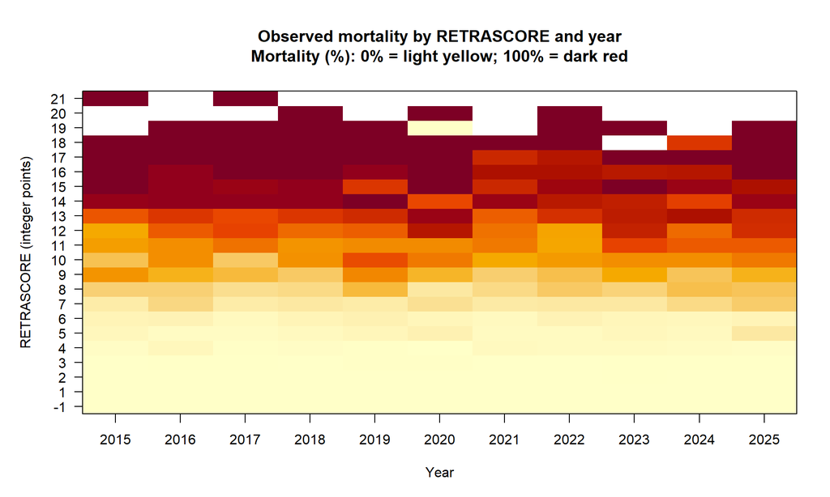

Observed mortality percentage by integer RETRASCORE and year.

```r
plot_metric_heatmap(score_year_summary, "mortality_percent",
                    "Observed mortality by RETRASCORE and year", "Mortality (%)")
```

```r
grDevices::png(file.path("outputs", "mortality_by_retrascore_year.png"), width = 1600, height = 900,
               res = 150)
plot_metric_heatmap(score_year_summary, "mortality_percent",
                    "Observed mortality by RETRASCORE and year", "Mortality (%)")
grDevices::dev.off()
```

## 6.2 Classification accuracy by RETRASCORE and year

Each cell is classification accuracy among evaluable patients for that exact integer score and year. Classification uses the reported probability cutoff (0.5 in this analysis). Blank cells have no evaluable patients.

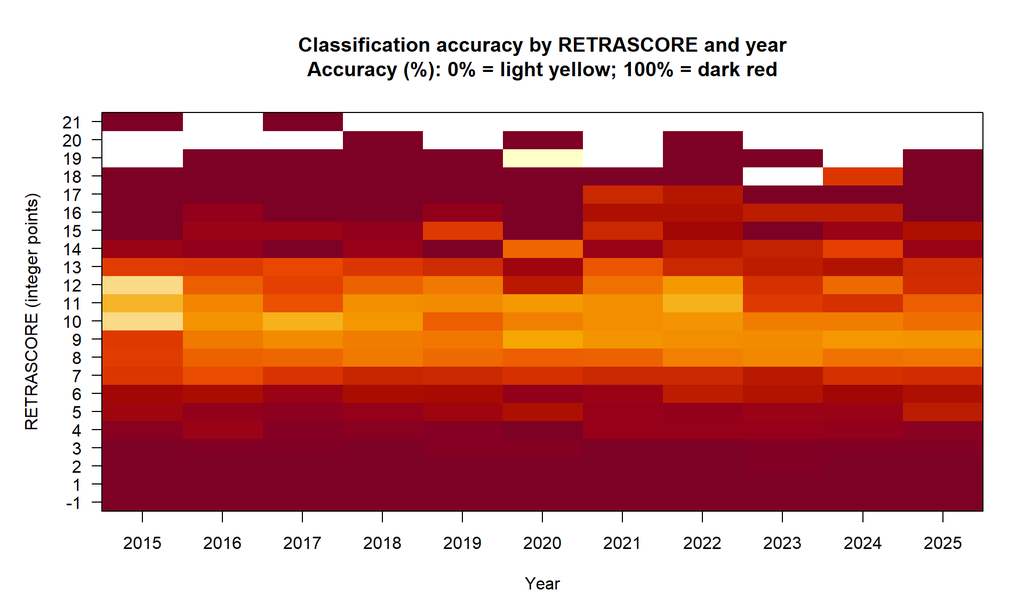

Classification accuracy percentage by integer RETRASCORE and year.

```r
plot_metric_heatmap(score_year_summary, "accuracy_percent",
                    "Classification accuracy by RETRASCORE and year", "Accuracy (%)")
```

```r
grDevices::png(file.path("outputs", "accuracy_by_retrascore_year.png"), width = 1600, height = 900,
               res = 150)
plot_metric_heatmap(score_year_summary, "accuracy_percent",
                    "Classification accuracy by RETRASCORE and year", "Accuracy (%)")
grDevices::dev.off()
```

# 7 Annual trends for each integer RETRASCORE

The following small multiples show one RETRASCORE value at a time. The red line is **observed mortality (%)** and its denominator is the number with a known death outcome. The blue line is **classification accuracy (%)** and its denominator is the number with both a known outcome and a calculated probability. Accuracy uses the reported probability cutoff (**0.5 in this analysis**). Each point label gives the percentage to one decimal place and its denominator as `n`; years without an estimable percentage are left as gaps rather than plotted as zero. The complete counts and numerators remain available in the score-by-year table above and in `outputs/retrascore_score_year_summary.csv`.

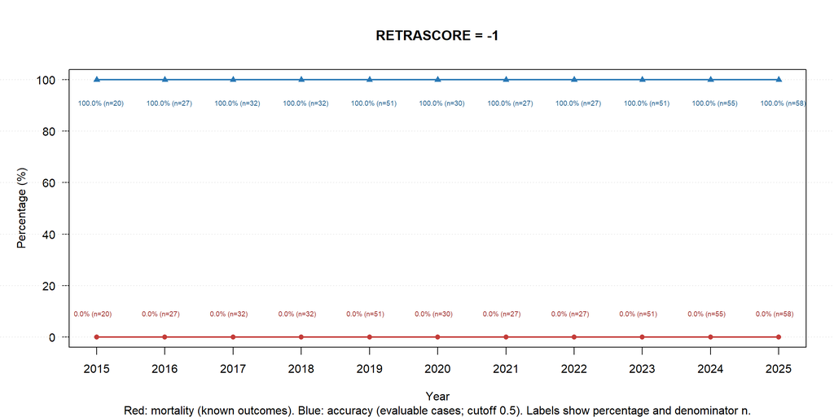

Annual observed mortality and classification accuracy for each integer RETRASCORE. Point labels show percentage and denominator.

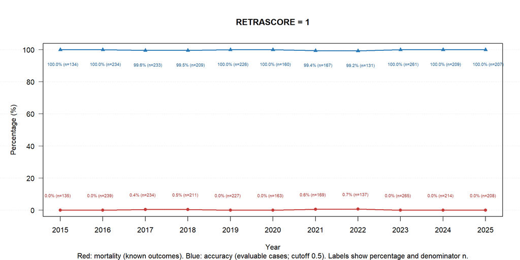

Annual observed mortality and classification accuracy for each integer RETRASCORE. Point labels show percentage and denominator.

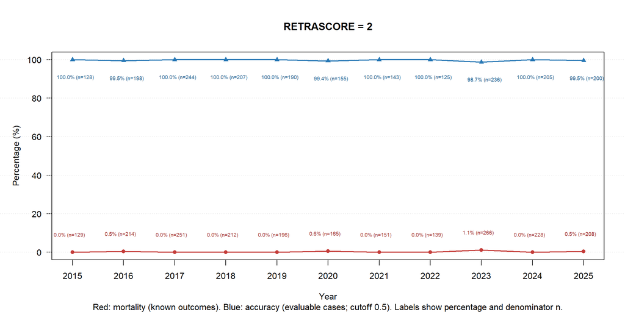

Annual observed mortality and classification accuracy for each integer RETRASCORE. Point labels show percentage and denominator.

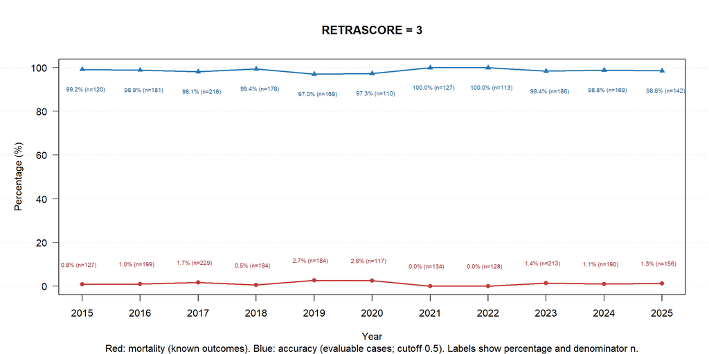

Annual observed mortality and classification accuracy for each integer RETRASCORE. Point labels show percentage and denominator.

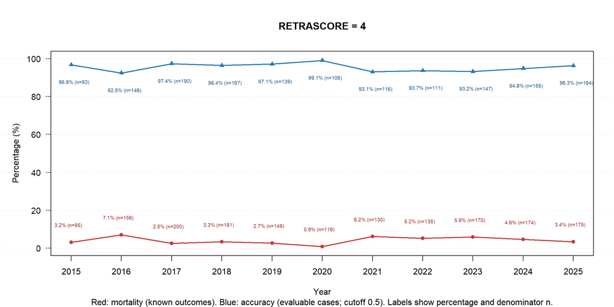

Annual observed mortality and classification accuracy for each integer RETRASCORE. Point labels show percentage and denominator.

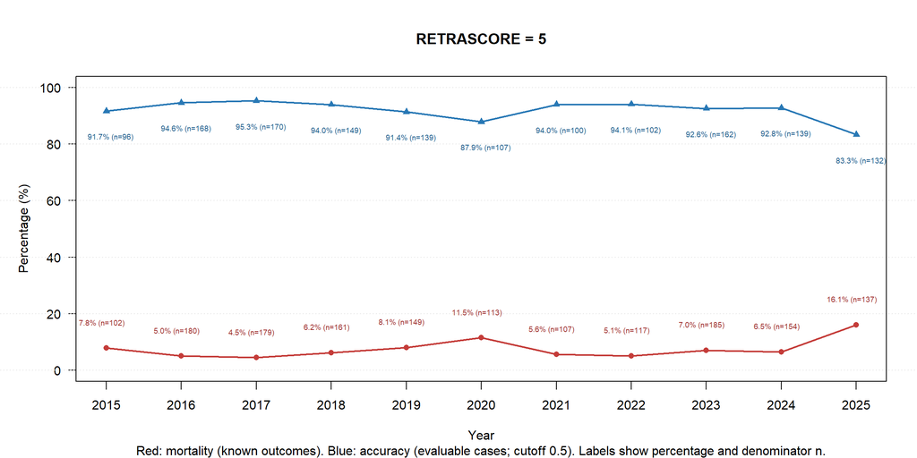

Annual observed mortality and classification accuracy for each integer RETRASCORE. Point labels show percentage and denominator.

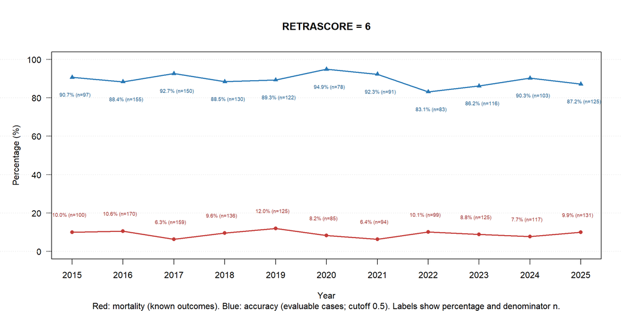

Annual observed mortality and classification accuracy for each integer RETRASCORE. Point labels show percentage and denominator.

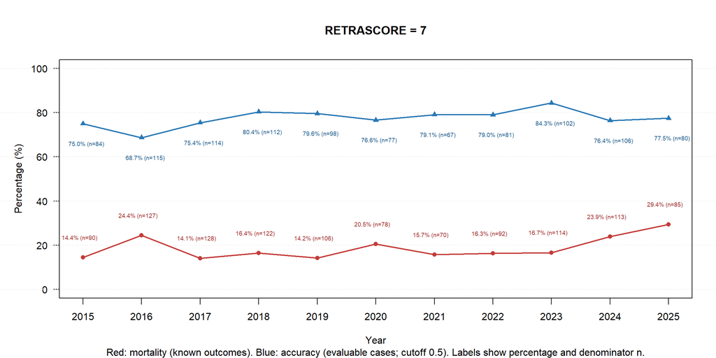

Annual observed mortality and classification accuracy for each integer RETRASCORE. Point labels show percentage and denominator.

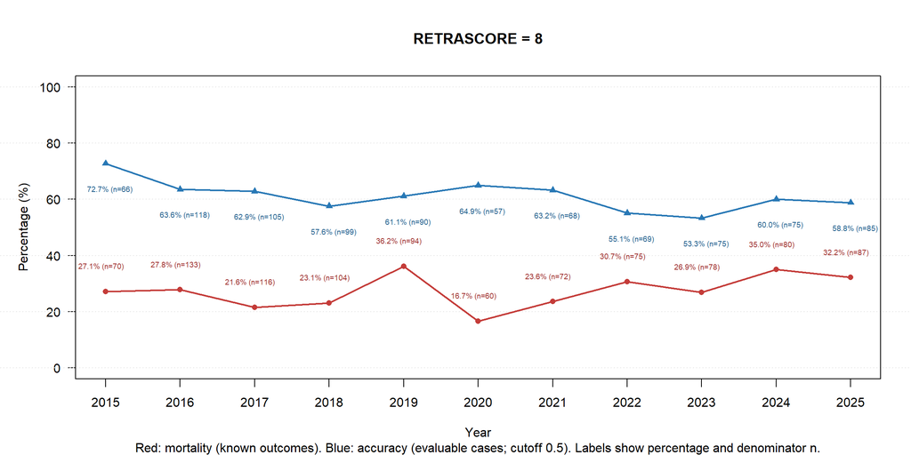

Annual observed mortality and classification accuracy for each integer RETRASCORE. Point labels show percentage and denominator.

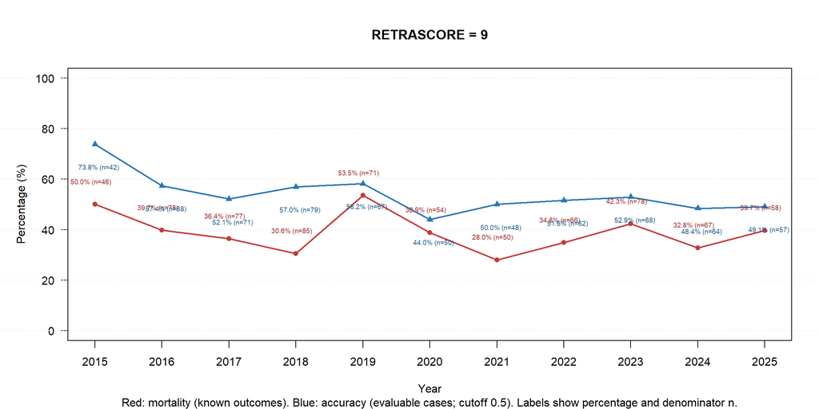

Annual observed mortality and classification accuracy for each integer RETRASCORE. Point labels show percentage and denominator.

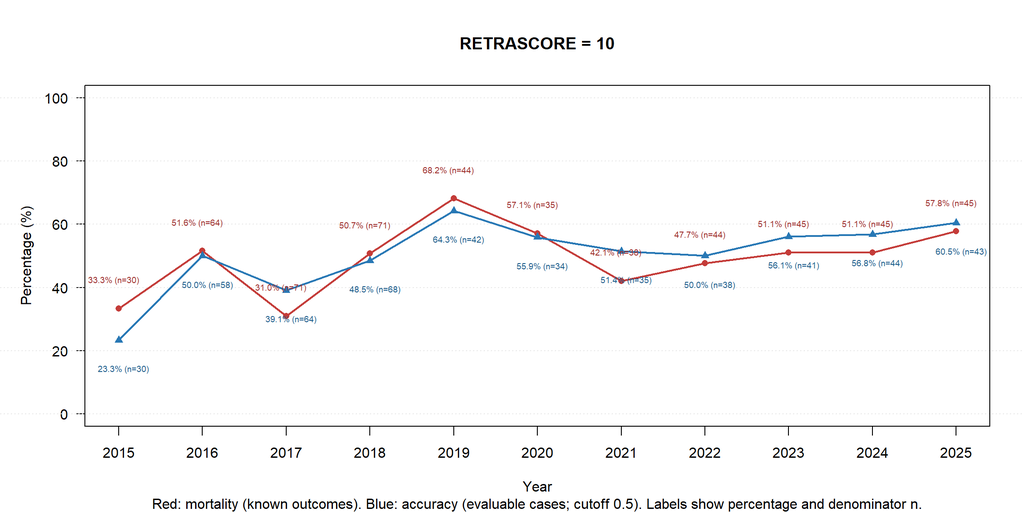

Annual observed mortality and classification accuracy for each integer RETRASCORE. Point labels show percentage and denominator.

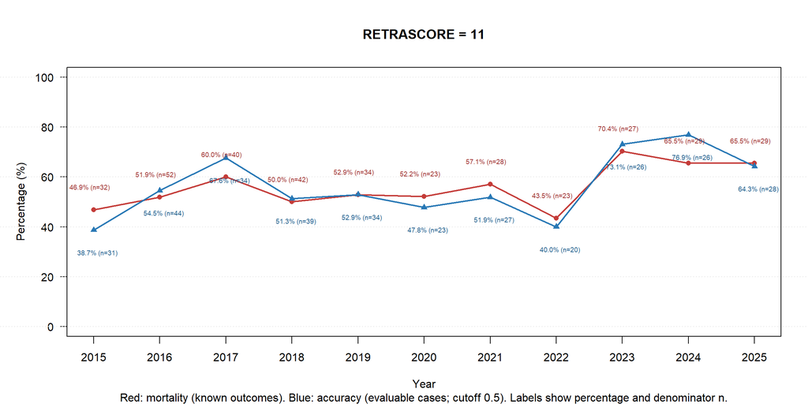

Annual observed mortality and classification accuracy for each integer RETRASCORE. Point labels show percentage and denominator.

[10 more figures not shown]

```r
plot_score_trend <- function(score_value, d, cutoff_value) {
  all_years <- sort(unique(year))
  score_data <- d[d$retrascore == score_value, , drop = FALSE]
  aligned <- data.frame(year = all_years)
  aligned <- merge(aligned, score_data, by = "year", all.x = TRUE, sort = TRUE)
  x <- seq_along(aligned$year)

  graphics::par(mar = c(5, 5, 5, 2), xpd = NA)
  graphics::plot(x, aligned$mortality_percent, type = "n", ylim = c(0, 100),
                 xaxt = "n", yaxt = "n", xlab = "Year", ylab = "Percentage (%)",
                 main = paste0("RETRASCORE = ", score_value),
                 sub = paste0("Red: mortality (known outcomes). Blue: accuracy (evaluable cases; cutoff ",
                              format(cutoff_value), "). Labels show percentage and denominator n."))
  graphics::axis(1, at = x, labels = aligned$year)
  graphics::axis(2, at = seq(0, 100, 20), las = 1)
  graphics::abline(h = seq(0, 100, 20), col = "grey90", lty = 3)

  graphics::lines(x, aligned$mortality_percent, type = "o", pch = 16, lwd = 2,
                  col = "#C43C39")
  graphics::lines(x, aligned$accuracy_percent, type = "o", pch = 17, lwd = 2,
                  col = "#2878B5")

  mortality_ok <- !is.na(aligned$mortality_percent)
  accuracy_ok <- !is.na(aligned$accuracy_percent)
  graphics::text(x[mortality_ok] - 0.06, aligned$mortality_percent[mortality_ok],
                 labels = sprintf("%.1f%% (n=%d)", aligned$mortality_percent[mortality_ok],
                                  aligned$death_outcome_n[mortality_ok]),
                 pos = 3, offset = 1.5, cex = 0.60, col = "#9E2F2D")
  graphics::text(x[accuracy_ok] + 0.06, aligned$accuracy_percent[accuracy_ok],
                 labels = sprintf("%.1f%% (n=%d)", aligned$accuracy_percent[accuracy_ok],
                                  aligned$accuracy_evaluable_n[accuracy_ok]),
                 pos = 1, offset = 1.5, cex = 0.60, col = "#1F5E8C")
  graphics::box()
}

trend_dir <- file.path("outputs", "retrascore_score_trends")
dir.create(trend_dir, showWarnings = FALSE, recursive = TRUE)

for (score_value in score_levels) {
  # Plot once for inclusion in the compiled report.
  plot_score_trend(score_value, score_year_summary, cutoff)

  # Also save a clearly named standalone PNG for this exact integer score.
  score_tag <- if (score_value < 0) paste0("minus", abs(score_value)) else sprintf("%02d", score_value)
  trend_file <- file.path(trend_dir, paste0("retrascore_", score_tag, "_annual_trends.png"))
  grDevices::png(trend_file, width = 1800, height = 900, res = 150)
  plot_score_trend(score_value, score_year_summary, cutoff)
  grDevices::dev.off()
}
```

# 8 Reproducibility

```r
cat("Rendered:", format(Sys.time(), tz = "UTC"), "UTC\n")
```

```
## Rendered: 2026-09-17 09:02:02 UTC
```